# Time Series Final Report

NARMADA, Nicholas (1A172G29-2)

2020-08-03

## Introduction

Since turning 20 years old, I am finally eligible to buy my own stocks in Japan. It has always been my interest in buying stocks and identifying when to buy what stocks has been difficult. After learning this Time Series Analysis course, I figured that I could use seasonality testing to check when to buy which stock in the future. This paper is aimed to figure out whether there are seasonality patterns among stocks within the same sector, and forecast the ups and downs in the next few months. Stocks from the same sector could potentially grow together in value, which could be attractive to investors who specialize in one particular sector.

The Global Industry Classification Standard (GISC) was created by MSCI and Standard and Poor’s (S&P), who are renowned index providers. It starts with 11 sectors, which can be further sub-divided into 24 industry groups, 68 industries, and 157 sub-industries.

The 11 GICS sectors are as follows:

1. Energy
2. Materials
3. Industrials
4. Consumer Discretionary
5. Consumer Staples
6. Health Care
7. Financials
8. Information Technology
9. Telecommunication Services
10. Utilities
11. Real Estate

There are several investment companies that offer security products that track these 11 sectors. An example is Vanguard, which created Exchange Traded Funds (ETFs) to mirror these GICS sectors. An ETF is a type of security that is a collection of securities, such as stocks, that tracks a certain index. In this case, the ETFs offered is a sector-specific ETF and tracks the GICS sectors.

Out of the sector-specific ETFs Vanguard offers, only 6 of them are currently available to be traded in Japan through the SBI Securities broker. They are the Materials, Consumer Discretionary, Consumer Staples, Financials, Health Care and Industrials ETF.

In order to forecast the future stock prices, this paper would use the Seasonal Autoregressive Integrated Moving Average (ARIMA) model and check which particular months are a sector’s lows and highs.

## Model and Data

I have retrieved the following Vanguard ETFs’ historical stock prices from Yahoo Finance (ticker symbols are in parentheses):

- Vanguard Materials ETF (VAW)
- Vanguard Consumer Discretionary ETF (VCR)
- Vanguard Consumer Staples ETF (VDC)
- Vanguard Financials ETF (VFH)
- Vanguard Health Care ETF (VHT)
- Vanguard Industrials ETF (VIS)

This paper would use the adjusted closing price instead of closing price as it accurately reflects a stock’s value after factoring in company actions that happen after the market closes. It has historically been considered as the “true price of a stock” and is widely used when examining for historical returns.

To check whether the adjusted closing prices have seasonalities and trends, this paper uses the decompose function to break down the adjusted closing prices of the ETFs to the different components.

*Note: To make the report easier to navigate, this paper separates the ETFs into “tabs” and hides codes. To check for the code, please click the “Code” button on the right of each block, and a drop down of the code should pop out

```r
library(tidyverse)
library(tseries)
library(forecast)
library(vars)
library(astsa)
library(pdp)

#reading all 6 files
VAW <- read.csv("VAW.csv")
VCR <- read.csv("VCR.csv")
VDC <- read.csv("VDC.csv")
VFH <- read.csv("VFH.csv")
VHT <- read.csv("VHT.csv")
VIS <- read.csv("VIS.csv")

#only get (Date) and (Adj Close) for data frame construction
DF.VAW <- data.frame(VAW[, c("Date", "Adj.Close")])
DF.VCR <- data.frame(VCR[, c("Date", "Adj.Close")])
DF.VDC <- data.frame(VDC[, c("Date", "Adj.Close")])
DF.VFH <- data.frame(VFH[, c("Date", "Adj.Close")])
DF.VHT <- data.frame(VHT[, c("Date", "Adj.Close")])
DF.VIS <- data.frame(VIS[, c("Date", "Adj.Close")])

#rename the column Adj.close to make it unique per ETF
colnames(DF.VAW)[2] <- "VAW_Adj.close"
colnames(DF.VCR)[2] <- "VCR_Adj.close"
colnames(DF.VDC)[2] <- "VDC_Adj.close"
colnames(DF.VFH)[2] <- "VFH_Adj.close"
colnames(DF.VHT)[2] <- "VHT_Adj.close"
colnames(DF.VIS)[2] <- "VIS_Adj.close"

#only includes date where all data are available
DF1 <- merge(DF.VCR, DF.VAW, by='Date')
DF2 <- merge(DF1, DF.VDC, by='Date')
DF3 <- merge(DF2, DF.VFH, by='Date')
DF4 <- merge(DF3, DF.VHT, by='Date')
DF_F <- as.data.frame(merge(DF4, DF.VIS, by='Date'))

DF_F <- DF_F %>%
  mutate(Date=as.Date(Date))

#convert to TS data frame
data.ts_VAW<- ts(DF_F$VAW_Adj.close, start = c(2004,9), end = c(2020,7), frequency = 12)
data.ts_VCR<- ts(DF_F$VCR_Adj.close, start = c(2004,9), end = c(2020,7), frequency = 12)
data.ts_VDC<- ts(DF_F$VDC_Adj.close, start = c(2004,9), end = c(2020,7), frequency = 12)
data.ts_VFH<- ts(DF_F$VFH_Adj.close, start = c(2004,9), end = c(2020,7), frequency = 12)
data.ts_VHT<- ts(DF_F$VHT_Adj.close, start = c(2004,9), end = c(2020,7), frequency = 12)
data.ts_VIS<- ts(DF_F$VIS_Adj.close, start = c(2004,9), end = c(2020,7), frequency = 12)
```

### Decomposition

#### VAW

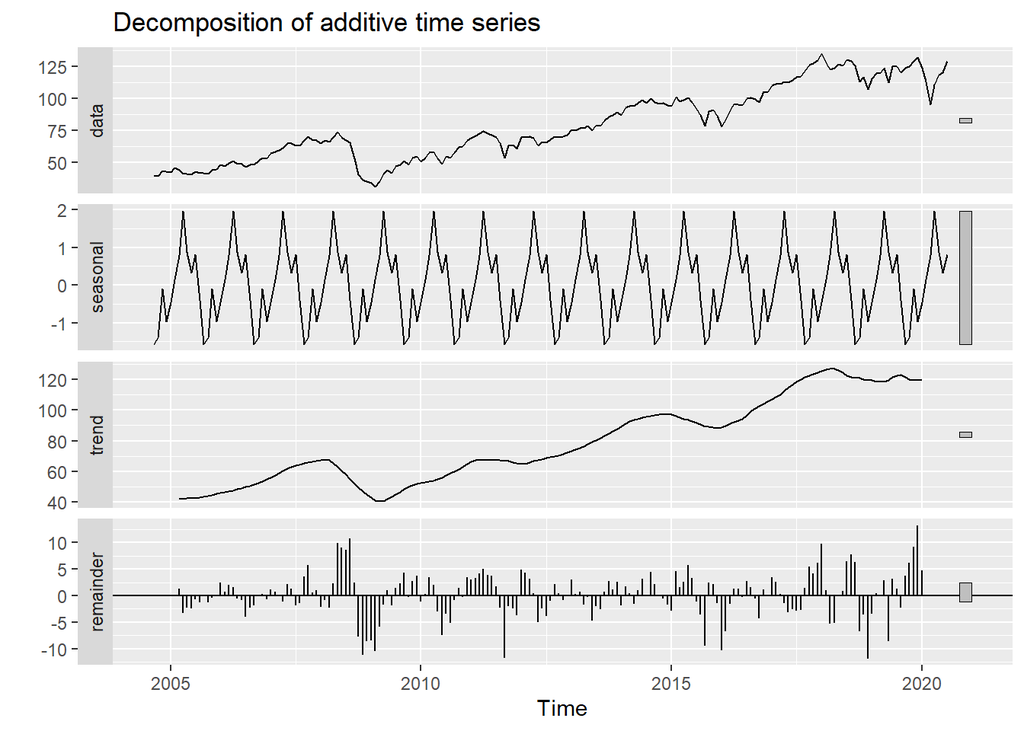

```r
data.ts_VAW %>% decompose %>% autoplot
```

#### VCR

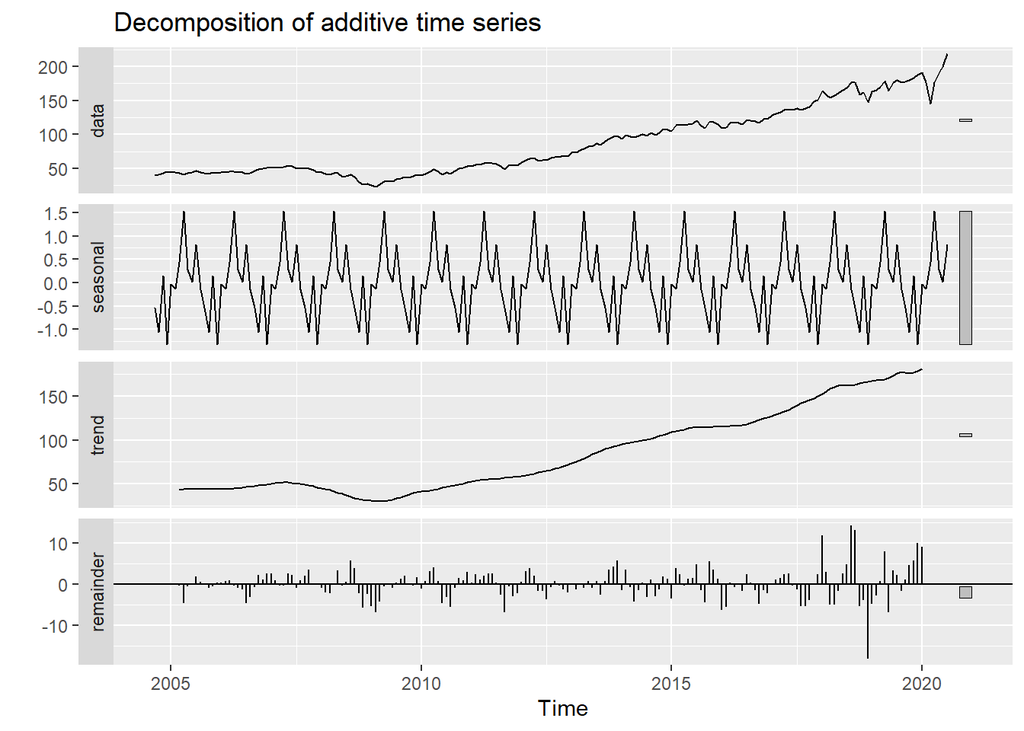

```r
data.ts_VCR %>% decompose %>% autoplot
```

#### VDC

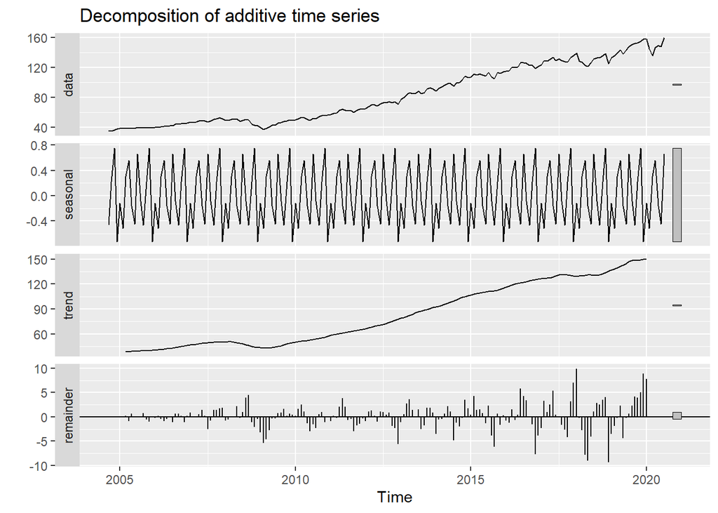

```r
data.ts_VDC %>% decompose %>% autoplot
```

#### VFH

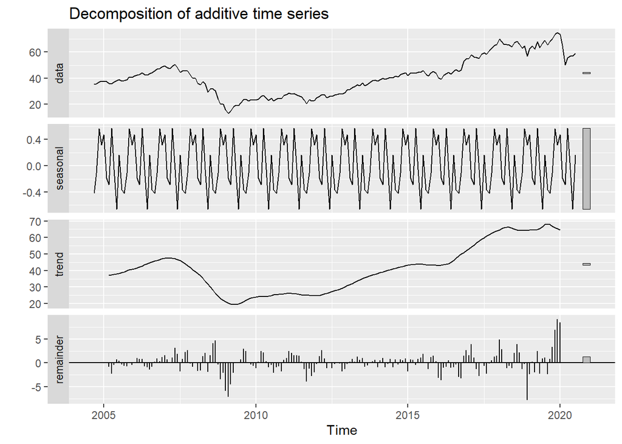

```r
data.ts_VFH %>% decompose %>% autoplot
```

#### VHT

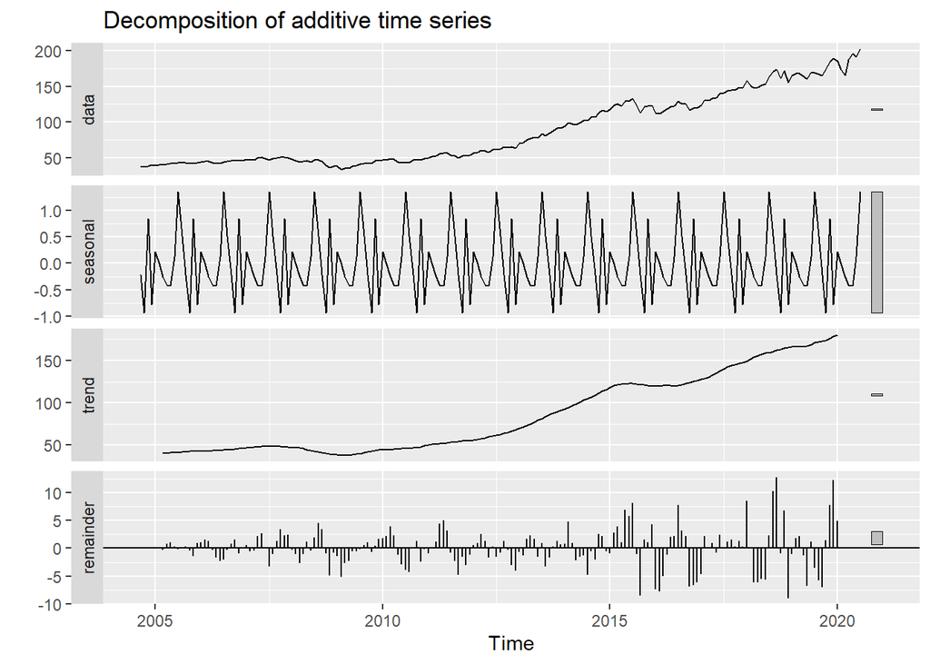

```r
data.ts_VHT %>% decompose %>% autoplot
```

#### VIS

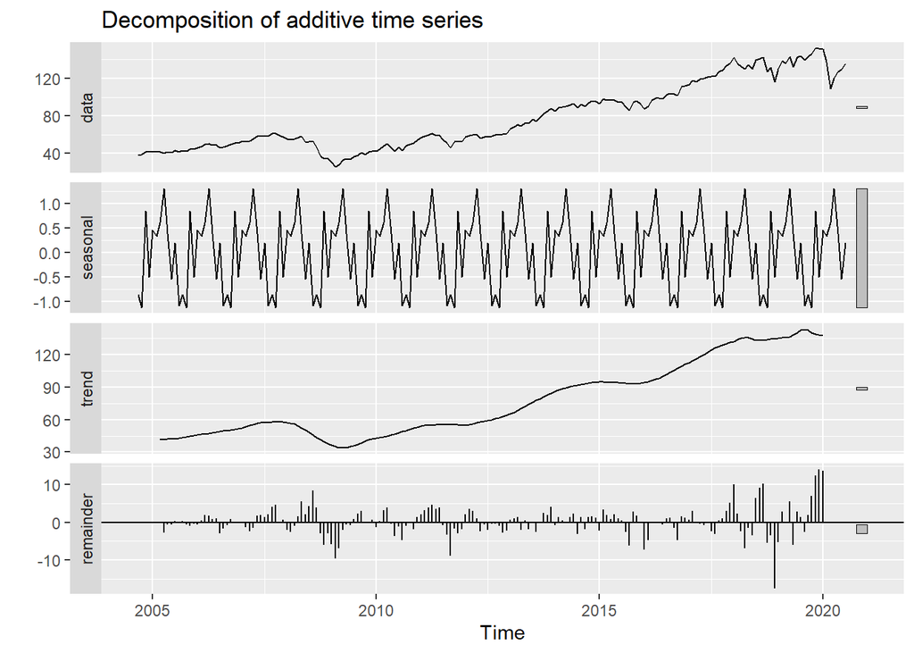

```r
data.ts_VIS %>% decompose %>% autoplot
```

Based on the decomposition of each ETF’s adjusted closing price, we can see that each of them has a trend and seasonal factor. Before fitting the data into the SARIMA model, there is a need to conduct differencing to remove the trend and seasonal components.

## Model Fitting

### Differencing

This paper uses the ndiffs() function to quickly calculate the number of differencing needed to make the time series data trend stationary. For the seasonal component, this paper uses a difference of 12 to remove the seasonality by 1 year. The values are then used as the number of differences, which then produces the graphs as shown below.

#### VAW

```r
diff12_VAW=diff(data.ts_VAW, 12)
ndiffs(na.remove(data.ts_VAW)) #compute for the number of differencing needed to make the data stationary
```

```
## [1] 1
```

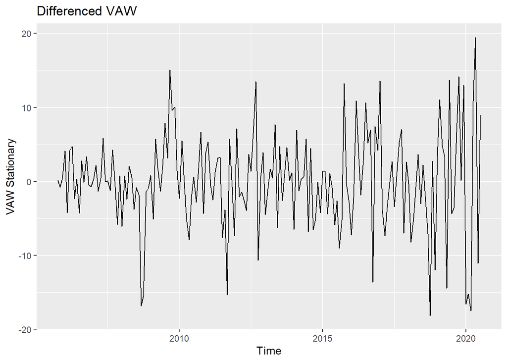

```r
#result: 1
data.ts_VAW_stationary <- diff(diff12_VAW, 1) #get the differenced data

autoplot(data.ts_VAW_stationary, ylab = "VAW Stationary", main = "Differenced VAW")
```

#### VCR

```r
diff12_VCR=diff(data.ts_VCR, 12)
ndiffs(na.remove(data.ts_VCR)) #compute for the number of differencing needed to make the data stationary
```

```
## [1] 1
```

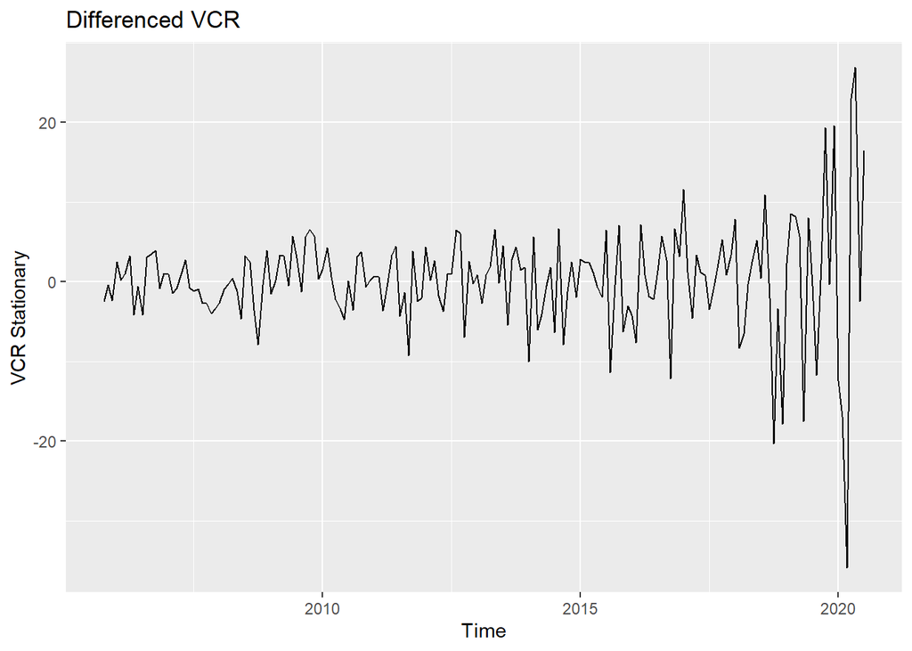

```r
#result: 1
data.ts_VCR_stationary <- diff(diff12_VCR, differences= 1) #get the differenced data

autoplot(data.ts_VCR_stationary, ylab = "VCR Stationary", main = "Differenced VCR")
```

#### VDC

```r
diff12_VDC=diff(data.ts_VDC, 12)
ndiffs(na.remove(data.ts_VDC)) #compute for the number of differencing needed to make the data stationary
```

```
## [1] 1
```

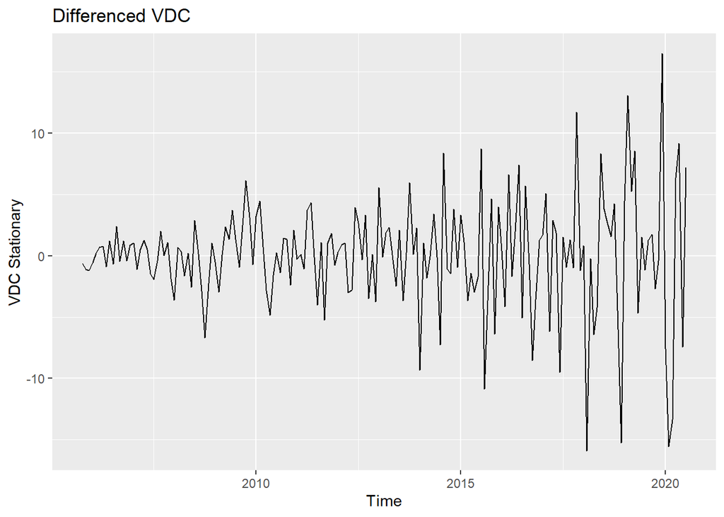

```r
#result: 1
data.ts_VDC_stationary <- diff(diff12_VDC, differences= 1) #get the differenced data

autoplot(data.ts_VDC_stationary, ylab = "VDC Stationary", main = "Differenced VDC")
```

#### VFH

```r
diff12_VFH=diff(data.ts_VFH, 12)
ndiffs(na.remove(data.ts_VFH)) #compute for the number of differencing needed to make the data stationary
```

```
## [1] 1
```

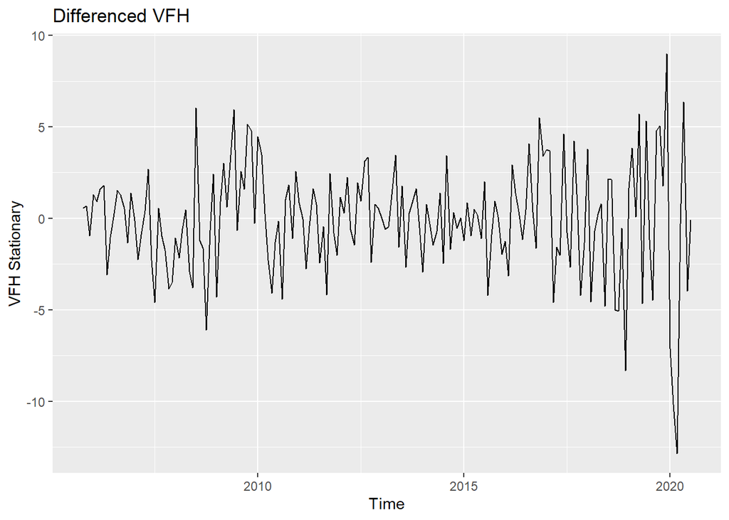

```r
#result: 1
data.ts_VFH_stationary <- diff(diff12_VFH, differences= 1) #get the differenced data

autoplot(data.ts_VFH_stationary, ylab = "VFH Stationary", main = "Differenced VFH")
```

#### VHT

```r
diff12_VHT=diff(data.ts_VHT, 12)
ndiffs(na.remove(data.ts_VHT)) #compute for the number of differencing needed to make the data stationary
```

```
## [1] 2
```

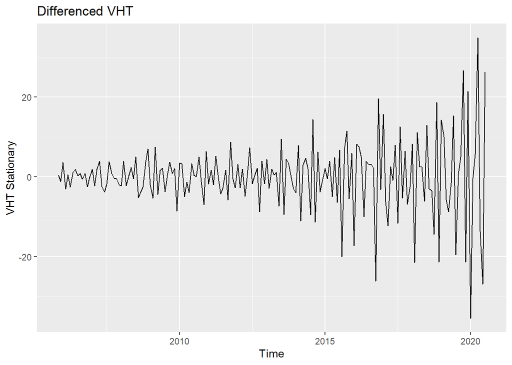

```r
#result: 2
data.ts_VHT_stationary <- diff(diff12_VHT, differences= 2) #get the differenced data

autoplot(data.ts_VHT_stationary, ylab = "VHT Stationary", main = "Differenced VHT")
```

#### VIS

```r
diff12_VIS=diff(data.ts_VIS, 12)
ndiffs(na.remove(data.ts_VIS)) #compute for the number of differencing needed to make the data stationary
```

```
## [1] 1
```

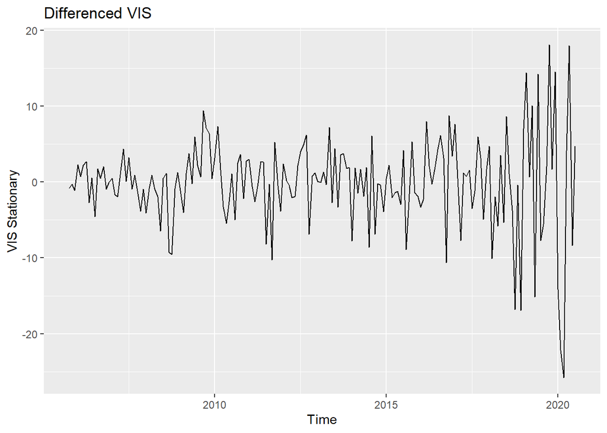

```r
#result: 1
data.ts_VIS_stationary <- diff(diff12_VIS, differences= 1) #get the differenced data

autoplot(data.ts_VIS_stationary, ylab = "VIS Stationary", main = "Differenced VIS")
```

### ACF and PACF Plots

After conducting differencing, this would plot the seasonal ACF and PACF of the differenced data to guess the possible seasonal ARIMA model which is the best fit. (For the ACF and PACF plots, Lag 1 indicates 1 full year’s worth of lag, thus it would be equivalent to lag 12.)

#### VAW

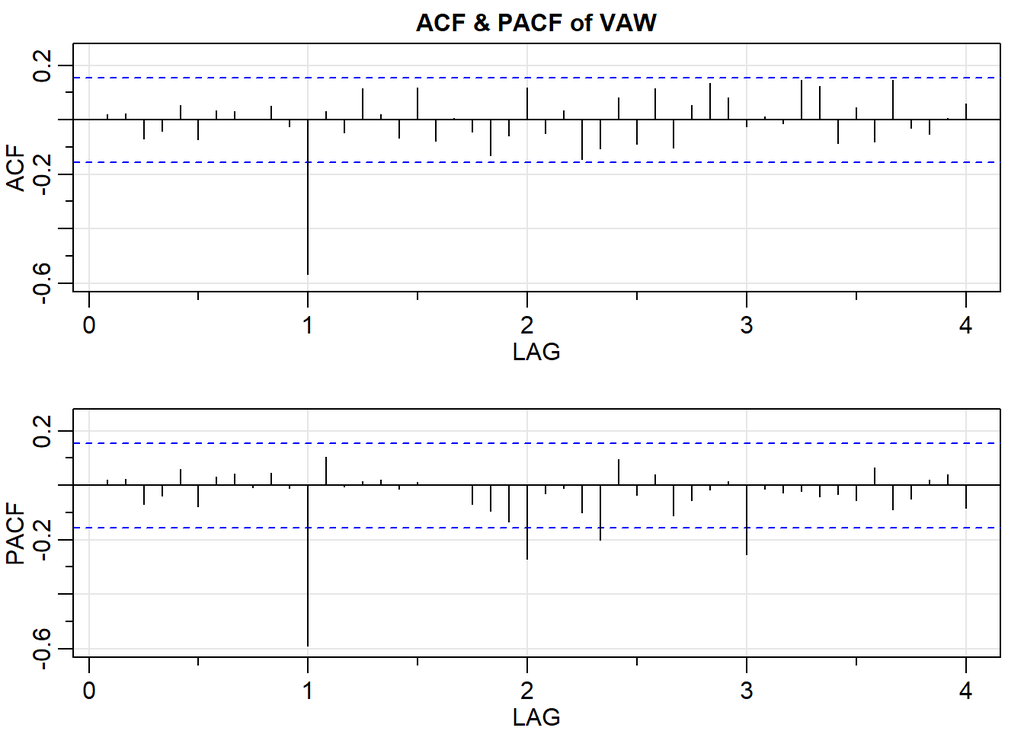

#### VCR

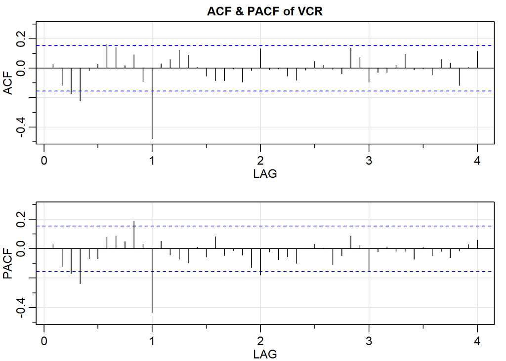

```r
#VCR seasonal ACF PACF
diff12.vcr = diff(vcr,12)
acf2(diff12.vcr, 48, main = "ACF & PACF of VCR")
```

#### VDC

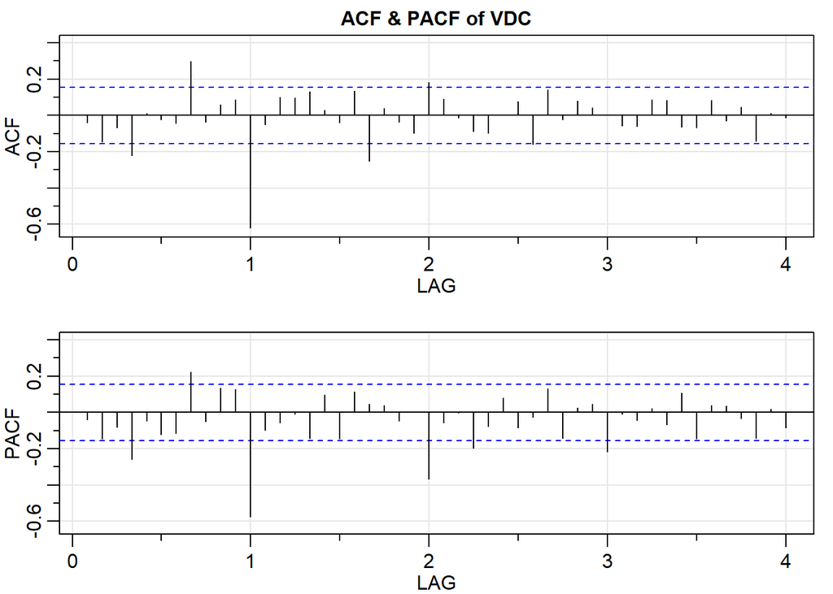

```r
#VDC seasonal ACF PACF
diff12.vdc = diff(vdc,12)
acf2(diff12.vdc, 48, main = "ACF & PACF of VDC")
```

#### VFH

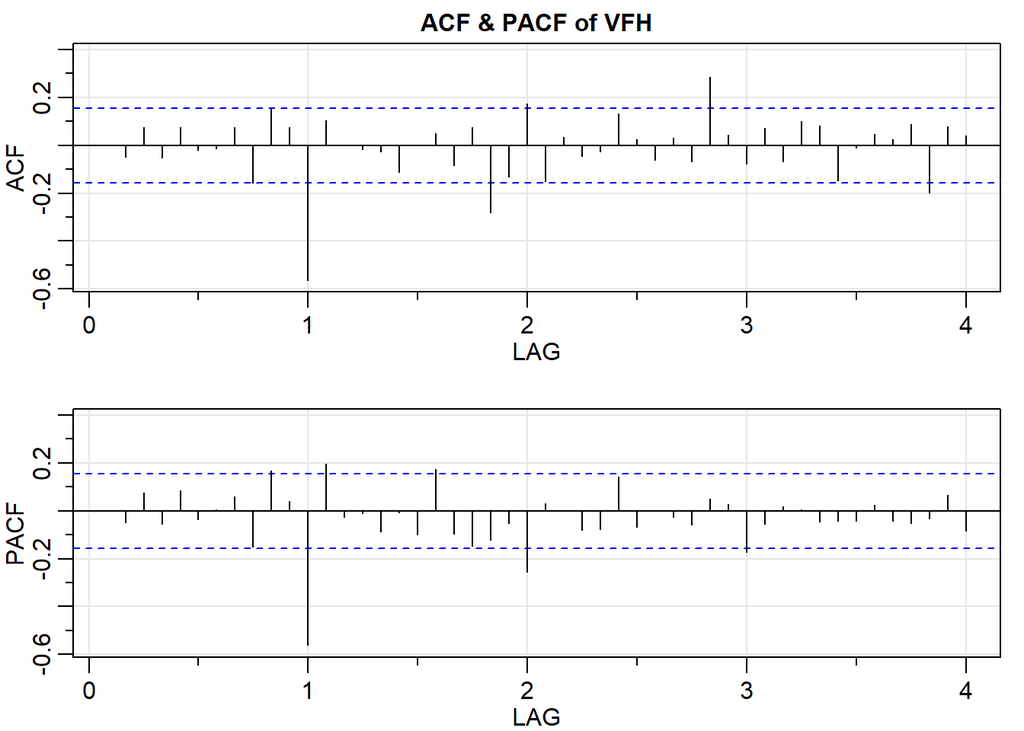

```r
#VFH seasonal ACF PACF
diff12.vfh = diff(vfh,12)
acf2(diff12.vfh, 48, main = "ACF & PACF of VFH")
```

#### VHT

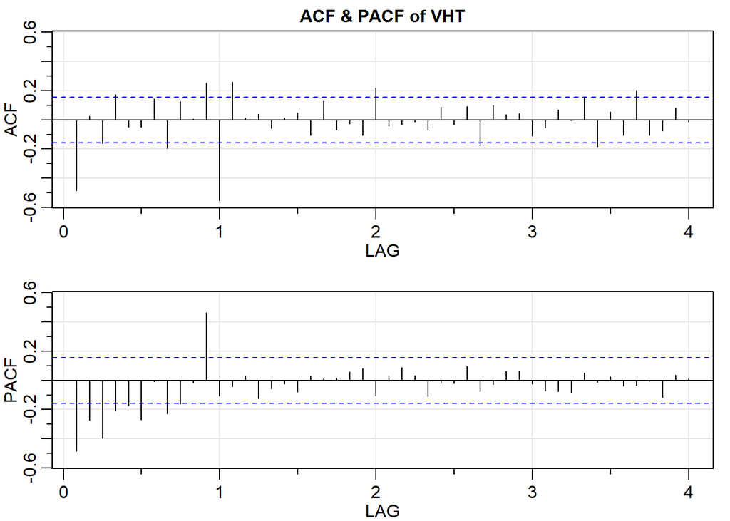

```r
#VHT seasonal ACF PACF
diff12.vht = diff(vht,12)
acf2(diff12.vht, 48, main = "ACF & PACF of VHT")
```

#### VIS

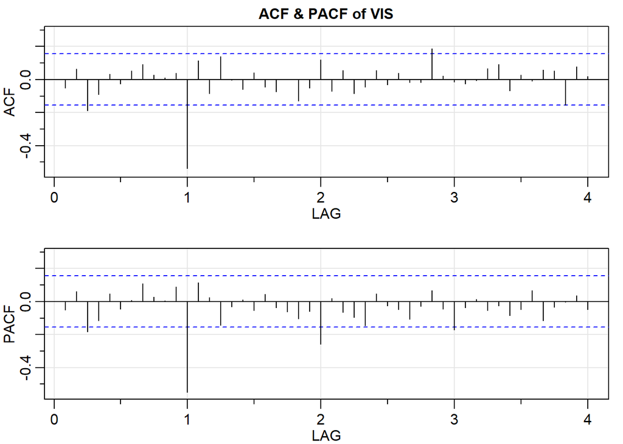

```r
#VIS seasonal ACF PACF
diff12.vis = diff(vis,12)
acf2(diff12.vis, 48, main = "ACF & PACF of VIS")
```

### SARIMA Model

After plotting the ACF and PACF models, also with the help of the auto.arima function, this paper would construct the following SARIMA model for each of the ETFs. The results of each ETFs’ auto.arima are also as shown below.

#### VAW

**VAW: SARIMA(0,1,0)(0,1,1)[12]**

```r
auto.arima(data.ts_VAW)
```

```
## Series: data.ts_VAW
## ARIMA(0,1,0)
##
## sigma^2 estimated as 20.97:  log likelihood=-558.69
## AIC=1119.37   AICc=1119.4   BIC=1122.62
```

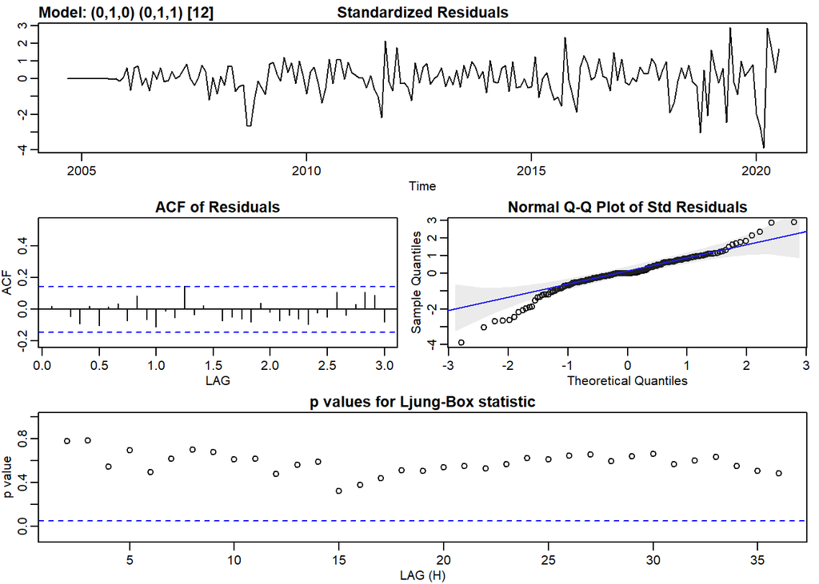

```
## $fit
##
## Call:
## stats::arima(x = xdata, order = c(p, d, q), seasonal = list(order = c(P, D,
##     Q), period = S), include.mean = !no.constant, transform.pars = trans, fixed = fixed,
##     optim.control = list(trace = trc, REPORT = 1, reltol = tol))
##
## Coefficients:
##          sma1
##       -0.9997
## s.e.   0.2253
##
## sigma^2 estimated as 21.07:  log likelihood = -540.35,  aic = 1084.7
##
## $degrees_of_freedom
## [1] 177
##
## $ttable
##      Estimate     SE t.value p.value
## sma1  -0.9997 0.2253 -4.4371       0
##
## $AIC
## [1] 5.739159
##
## $AICc
## [1] 5.739272
##
## $BIC
## [1] 5.772829
```

```r
sarima(data.ts_VAW,0,1,0,0,1,1,12)
```

#### VCR

**VCR: SARIMA(1,1,1)(0,2,1)[12]**

```r
auto.arima(data.ts_VCR)
```

```
## Series: data.ts_VCR
## ARIMA(1,1,1) with drift
##
## Coefficients:
##          ar1      ma1   drift
##       0.5988  -0.7483  0.8771
## s.e.  0.1493   0.1179  0.2507
##
## sigma^2 estimated as 30.1:  log likelihood=-591.55
## AIC=1191.11   AICc=1191.33   BIC=1204.1
```

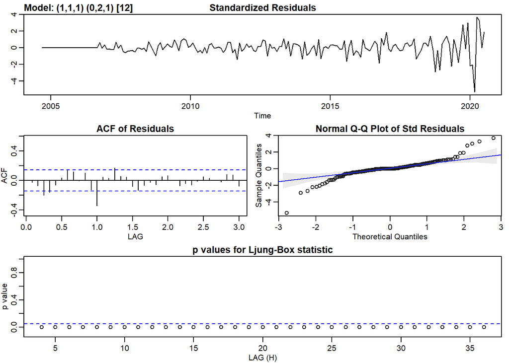

```
## $fit
##
## Call:
## stats::arima(x = xdata, order = c(p, d, q), seasonal = list(order = c(P, D,
##     Q), period = S), xreg = constant, transform.pars = trans, fixed = fixed,
##     optim.control = list(trace = trc, REPORT = 1, reltol = tol))
##
## Coefficients:
##           ar1     ma1     sma1  constant
##       -0.9212  0.9994  -0.9950    0.8891
## s.e.   0.0381  0.0352   0.0995  100.8693
##
## sigma^2 estimated as 45.88:  log likelihood = -574.81,  aic = 1159.63
##
## $degrees_of_freedom
## [1] 162
##
## $ttable
##          Estimate       SE  t.value p.value
## ar1       -0.9212   0.0381 -24.1736   0.000
## ma1        0.9994   0.0352  28.4284   0.000
## sma1      -0.9950   0.0995  -9.9989   0.000
## constant   0.8891 100.8693   0.0088   0.993
##
## $AIC
## [1] 6.168223
##
## $AICc
## [1] 6.169386
##
## $BIC
## [1] 6.250989
```

```r
sarima(data.ts_VCR,1,1,1,0,2,1,12)
```

#### VDC

**VDC: SARIMA(0,1,2)(1,1,1)[12]**

```r
auto.arima(data.ts_VDC)
```

```
## Series: data.ts_VDC
## ARIMA(0,1,2) with drift
##
## Coefficients:
##           ma1      ma2   drift
##       -0.1044  -0.2256  0.6376
## s.e.   0.0753   0.0860  0.1527
##
## sigma^2 estimated as 9.921:  log likelihood=-486.14
## AIC=980.29   AICc=980.5   BIC=993.28
```

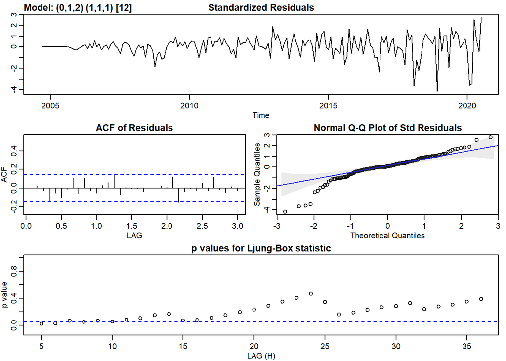

```
## $fit
##
## Call:
## stats::arima(x = xdata, order = c(p, d, q), seasonal = list(order = c(P, D,
##     Q), period = S), include.mean = !no.constant, transform.pars = trans, fixed = fixed,
##     optim.control = list(trace = trc, REPORT = 1, reltol = tol))
##
## Coefficients:
##           ma1      ma2     sar1     sma1
##       -0.0954  -0.1379  -0.2745  -0.6978
## s.e.   0.0788   0.1003   0.1222   0.1276
##
## sigma^2 estimated as 10.59:  log likelihood = -469.2,  aic = 948.4
##
## $degrees_of_freedom
## [1] 174
##
## $ttable
##      Estimate     SE t.value p.value
## ma1   -0.0954 0.0788 -1.2112  0.2275
## ma2   -0.1379 0.1003 -1.3753  0.1708
## sar1  -0.2745 0.1222 -2.2463  0.0259
## sma1  -0.6978 0.1276 -5.4696  0.0000
##
## $AIC
## [1] 5.017975
##
## $AICc
## [1] 5.019125
##
## $BIC
## [1] 5.102149
```

```r
sarima(data.ts_VDC,0,1,2,1,1,1,12)
```

#### VFH

**VFH: SARIMA(1,1,1)(0,1,1)[12]**

```r
auto.arima(data.ts_VFH)
```

```
## Series: data.ts_VFH
## ARIMA(1,1,1)(0,0,2)[12]
##
## Coefficients:
##           ar1     ma1    sma1    sma2
##       -0.8812  0.9842  0.1454  0.1999
## s.e.   0.0466  0.0221  0.0827  0.0900
##
## sigma^2 estimated as 5.523:  log likelihood=-430.77
## AIC=871.54   AICc=871.87   BIC=887.78
```

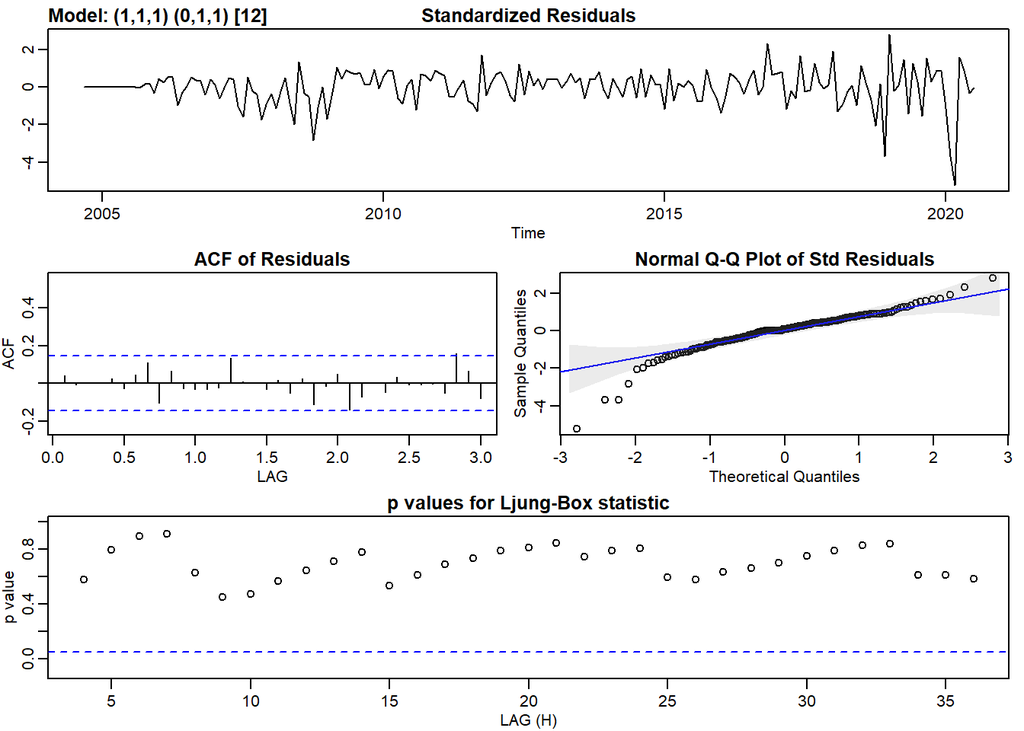

```
## $fit
##
## Call:
## stats::arima(x = xdata, order = c(p, d, q), seasonal = list(order = c(P, D,
##     Q), period = S), include.mean = !no.constant, transform.pars = trans, fixed = fixed,
##     optim.control = list(trace = trc, REPORT = 1, reltol = tol))
##
## Coefficients:
##           ar1     ma1     sma1
##       -0.8821  1.0000  -0.7092
## s.e.   0.0384  0.0264   0.0921
##
## sigma^2 estimated as 6.069:  log likelihood = -419.39,  aic = 846.77
##
## $degrees_of_freedom
## [1] 175
##
## $ttable
##      Estimate     SE  t.value p.value
## ar1   -0.8821 0.0384 -22.9572       0
## ma1    1.0000 0.0264  37.8446       0
## sma1  -0.7092 0.0921  -7.6990       0
##
## $AIC
## [1] 4.480287
##
## $AICc
## [1] 4.480973
##
## $BIC
## [1] 4.547626
```

```r
sarima(data.ts_VFH,1,1,1,0,1,1,12)
```

#### VHT

**VHT: SARIMA(0,2,4)(0,1,1)[12]**

```r
auto.arima(data.ts_VHT)
```

```
## Series: data.ts_VHT
## ARIMA(0,2,4)
##
## Coefficients:
##          ma1     ma2      ma3     ma4
##       -1.128  0.0667  -0.0988  0.1845
## s.e.   0.074  0.1108   0.1204  0.0750
##
## sigma^2 estimated as 18.31:  log likelihood=-542.78
## AIC=1095.56   AICc=1095.89   BIC=1111.77
```

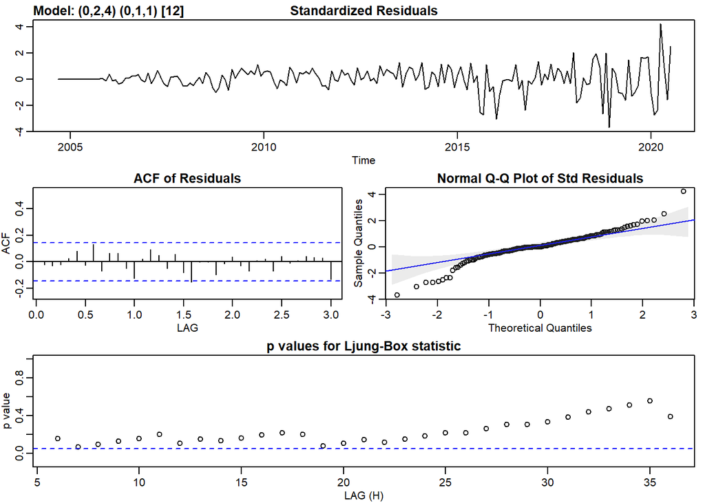

```
## $fit
##
## Call:
## stats::arima(x = xdata, order = c(p, d, q), seasonal = list(order = c(P, D,
##     Q), period = S), xreg = constant, transform.pars = trans, fixed = fixed,
##     optim.control = list(trace = trc, REPORT = 1, reltol = tol))
##
## Coefficients:
##           ma1     ma2      ma3     ma4     sma1  constant
##       -1.1224  0.0348  -0.1213  0.2096  -0.8843    0.8915
## s.e.   0.0907  0.1113   0.1226  0.0820   0.0872  152.6384
##
## sigma^2 estimated as 18.88:  log likelihood = -527.57,  aic = 1069.15
##
## $degrees_of_freedom
## [1] 171
##
## $ttable
##          Estimate       SE  t.value p.value
## ma1       -1.1224   0.0907 -12.3804  0.0000
## ma2        0.0348   0.1113   0.3122  0.7553
## ma3       -0.1213   0.1226  -0.9898  0.3237
## ma4        0.2096   0.0820   2.5554  0.0115
## sma1      -0.8843   0.0872 -10.1434  0.0000
## constant   0.8915 152.6384   0.0058  0.9953
##
## $AIC
## [1] 5.686942
##
## $AICc
## [1] 5.68941
##
## $BIC
## [1] 5.805203
```

```r
sarima(data.ts_VHT,0,2,4,0,1,1,12)
```

#### VIS

**VIS: SARIMA(0,1,0)(0,1,1)[12]**

```r
auto.arima(data.ts_VIS)
```

```
## Series: data.ts_VIS
## ARIMA(0,1,0) with drift
##
## Coefficients:
##        drift
##       0.5129
## s.e.  0.3268
##
## sigma^2 estimated as 20.41:  log likelihood=-555.6
## AIC=1115.19   AICc=1115.26   BIC=1121.69
```

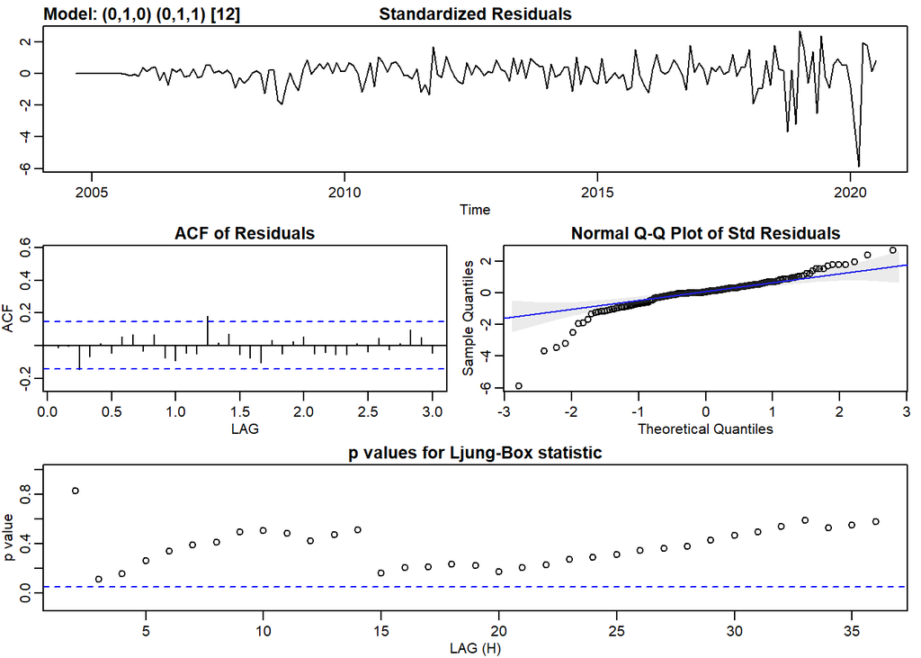

```
## $fit
##
## Call:
## stats::arima(x = xdata, order = c(p, d, q), seasonal = list(order = c(P, D,
##     Q), period = S), include.mean = !no.constant, transform.pars = trans, fixed = fixed,
##     optim.control = list(trace = trc, REPORT = 1, reltol = tol))
##
## Coefficients:
##          sma1
##       -0.7928
## s.e.   0.0797
##
## sigma^2 estimated as 22.6:  log likelihood = -536,  aic = 1076.01
##
## $degrees_of_freedom
## [1] 177
##
## $ttable
##      Estimate     SE t.value p.value
## sma1  -0.7928 0.0797 -9.9417       0
##
## $AIC
## [1] 5.693167
##
## $AICc
## [1] 5.69328
##
## $BIC
## [1] 5.726837
```

```r
sarima(data.ts_VIS,0,1,0,0,1,1,12)
```

## Results

### Forecast

After fitting each ETF into a seasonal ARIMA model, this paper would predict the adjusted closing prices of the next 24 months. The forecasts also includes the lower limit and the upper limit of the forecasts. The results of each ETF are as shown below.

#### VAW

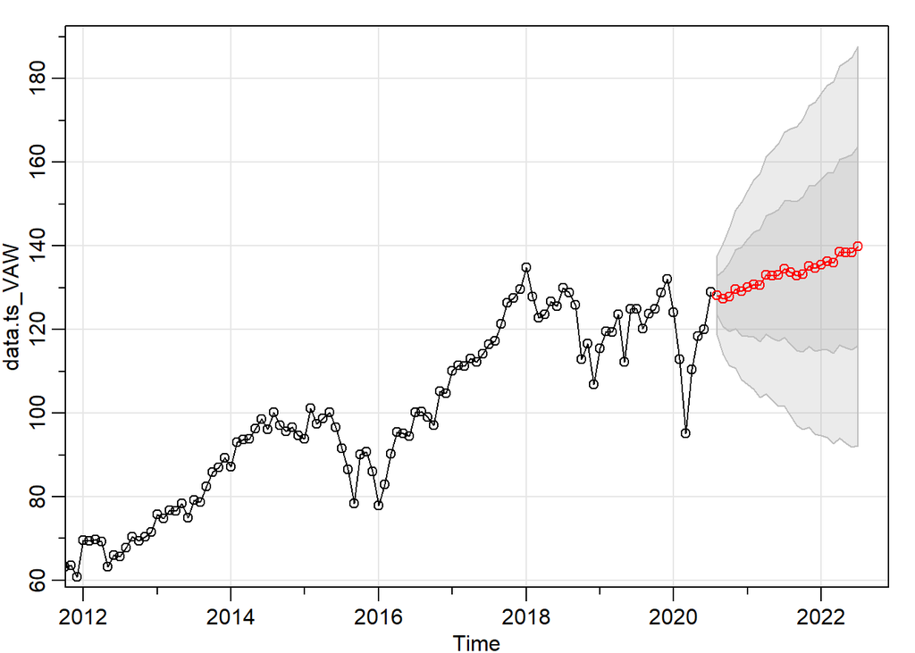

```
## $pred
##           Jan      Feb      Mar      Apr      May      Jun      Jul      Aug
## 2020                                                                128.1918
## 2021 130.0683 130.8289 130.5294 133.0261 132.9519 133.0006 134.4535 133.6653
## 2022 135.5417 136.3024 136.0029 138.4996 138.4254 138.4741 139.9269
##           Sep      Oct      Nov      Dec
## 2020 127.3516 127.7979 129.6303 129.2101
## 2021 132.8251 133.2714 135.1037 134.6836
## 2022
##
## $se
##            Jan       Feb       Mar       Apr       May       Jun       Jul
## 2020
## 2021 11.594012 12.521797 13.385427 14.196617 14.963897 15.693708 16.391056
## 2022 20.475169 21.076980 21.662078 22.231783 22.787249 23.329494 23.859418
##            Aug       Sep       Oct       Nov       Dec
## 2020  4.739411  6.702539  8.203554  9.469561 10.585219
## 2021 17.144577 17.866345 18.552974 19.215083 19.855125
## 2022
```

```r
sarima.for(data.ts_VAW, 24, 0,1,0,0,1,1,12)
```

#### VCR

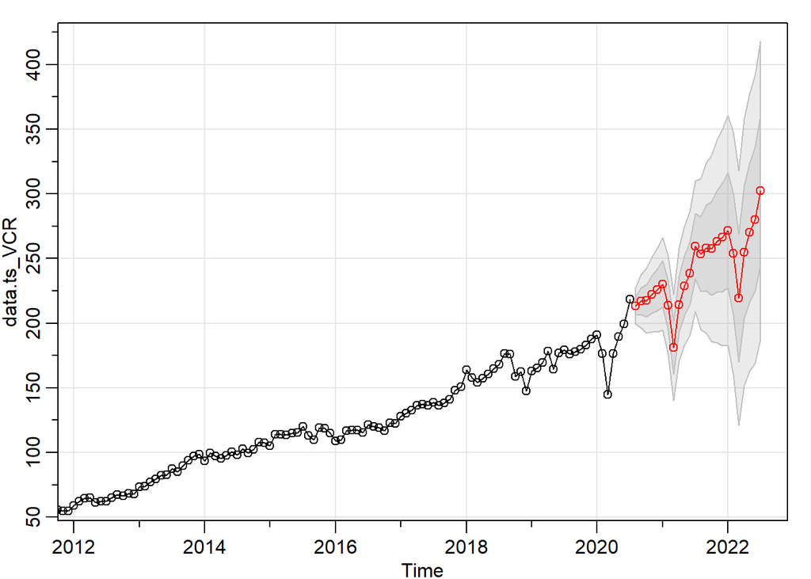

```
## $pred
##           Jan      Feb      Mar      Apr      May      Jun      Jul      Aug
## 2020                                                                213.3600
## 2021 230.3039 213.7450 180.9789 214.4594 228.8819 238.5415 259.3864 253.4245
## 2022 271.8138 253.7927 219.3918 254.7865 270.2672 280.1941 302.4882
##           Sep      Oct      Nov      Dec
## 2020 217.0582 217.3668 222.2434 225.7418
## 2021 258.0788 257.7339 263.3195 266.4124
## 2022
##
## $se
##            Jan       Feb       Mar       Apr       May       Jun       Jul
## 2020
## 2021 17.789457 19.160822 20.538362 21.744388 22.960785 24.051348 25.151218
## 2022 44.495626 46.882135 49.272899 51.447688 53.626727 55.639080 57.653070
##            Aug       Sep       Oct       Nov       Dec
## 2020  7.042122 10.285341 12.475748 14.529953 16.168354
## 2021 29.130514 32.925891 36.051738 39.140233 41.819819
## 2022
```

```r
sarima.for(data.ts_VCR, 24, 1,1,1,0,2,1,12)
```

#### VDC

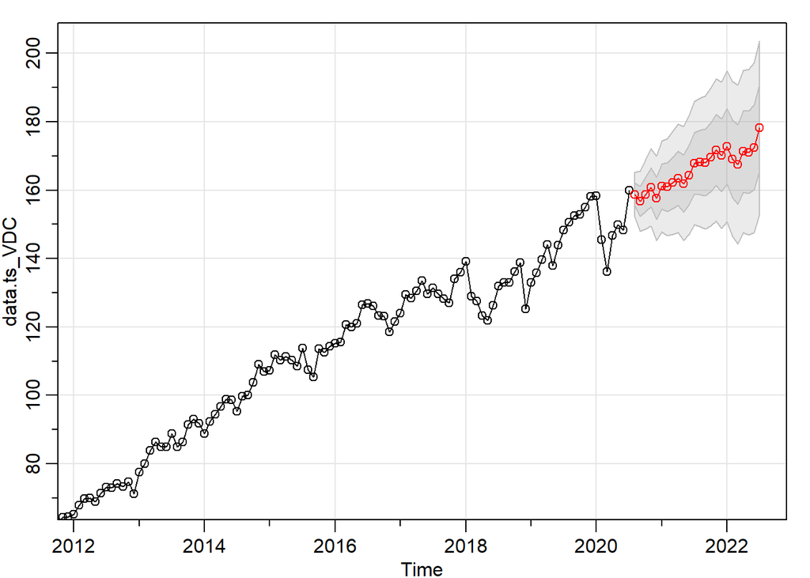

```
## $pred
##           Jan      Feb      Mar      Apr      May      Jun      Jul      Aug
## 2020                                                                158.7104
## 2021 161.1141 160.9141 162.1599 163.4252 161.9555 164.4055 167.8746 168.1201
## 2022 172.8320 169.1579 167.4815 171.3178 171.1115 172.4645 178.1659
##           Sep      Oct      Nov      Dec
## 2020 156.7819 158.7815 160.8445 157.5840
## 2021 168.0835 169.6343 171.7422 170.2086
## 2022
##
## $se
##            Jan       Feb       Mar       Apr       May       Jun       Jul
## 2020
## 2021  6.644963  7.097935  7.523684  7.926599  8.310001  8.676477  9.028090
## 2022 11.005956 11.300726 11.588000 11.868322 12.142174 12.409985 12.672137
##            Aug       Sep       Oct       Nov       Dec
## 2020  3.254142  4.388045  5.047781  5.630740  6.158765
## 2021  9.390970  9.738057 10.070009 10.391363 10.703072
## 2022
```

```r
sarima.for(data.ts_VDC, 24, 0,1,2,1,1,1,12)
```

#### VFH

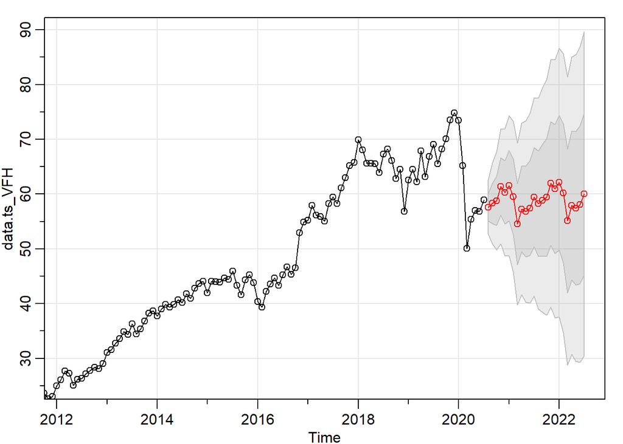

```
## $pred
##           Jan      Feb      Mar      Apr      May      Jun      Jul      Aug
## 2020                                                                57.60852
## 2021 61.53541 59.52808 54.51398 57.28041 56.83578 57.43303 59.45472 58.26745
## 2022 62.11223 60.15869 55.09715 57.90543 57.42389 58.05369 60.04667
##           Sep      Oct      Nov      Dec
## 2020 58.30208 58.75866 61.37872 60.30695
## 2021 58.86028 59.40571 61.94739 60.94476
## 2022
##
## $se
##            Jan       Feb       Mar       Apr       May       Jun       Jul
## 2020
## 2021  6.401742  6.890726  7.392954  7.825174  8.266520  8.658740  9.056503
## 2022 12.264329 12.712080 13.161551 13.581674 14.001587 14.398632 14.794147
##            Aug       Sep       Oct       Nov       Dec
## 2020  2.472563  3.695298  4.464217  5.226422  5.806547
## 2021  9.640617 10.237649 10.762900 11.296356 11.778113
## 2022
```

```r
sarima.for(data.ts_VFH, 24, 1,1,1,0,1,1,12)
```

#### VHT

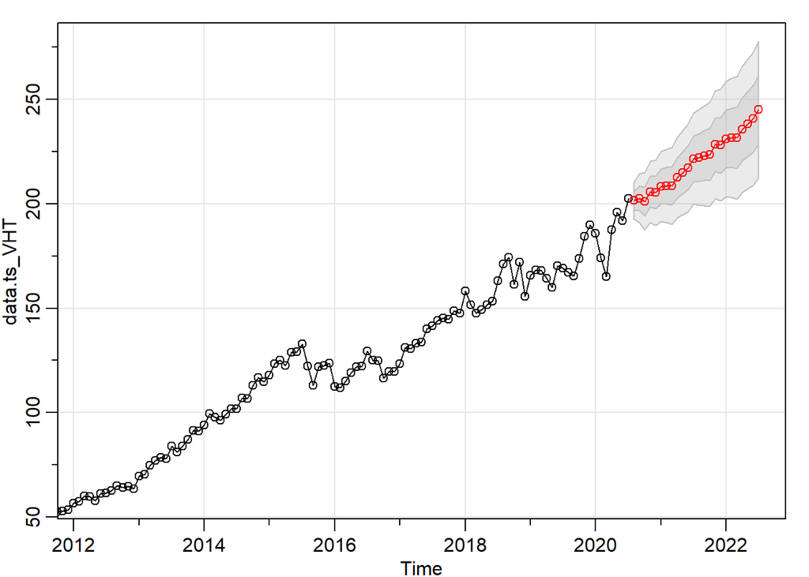

```
## $pred
##           Jan      Feb      Mar      Apr      May      Jun      Jul      Aug
## 2020                                                                201.5882
## 2021 208.2394 208.6412 208.5746 212.5074 214.9586 217.2915 221.5842 222.2491
## 2022 231.0891 231.6107 231.6639 235.7165 238.2875 240.7402 245.1527
##           Sep      Oct      Nov      Dec
## 2020 202.6926 201.1835 205.7631 205.3958
## 2021 223.0434 223.6738 228.3733 228.1258
## 2022
##
## $se
##            Jan       Feb       Mar       Apr       May       Jun       Jul
## 2020
## 2021  8.320820  8.774381  9.215366  9.645499 10.066174 10.478529 10.882574
## 2022 13.786678 14.224309 14.656983 15.085126 15.509116 15.929283 16.344641
##            Aug       Sep       Oct       Nov       Dec
## 2020  4.382414  5.863712  6.859416  7.366612  7.852502
## 2021 11.430840 11.944469 12.438774 12.894518 13.343602
## 2022
```

```r
sarima.for(data.ts_VHT, 24, 0,2,4,0,1,1,12)
```

#### VIS

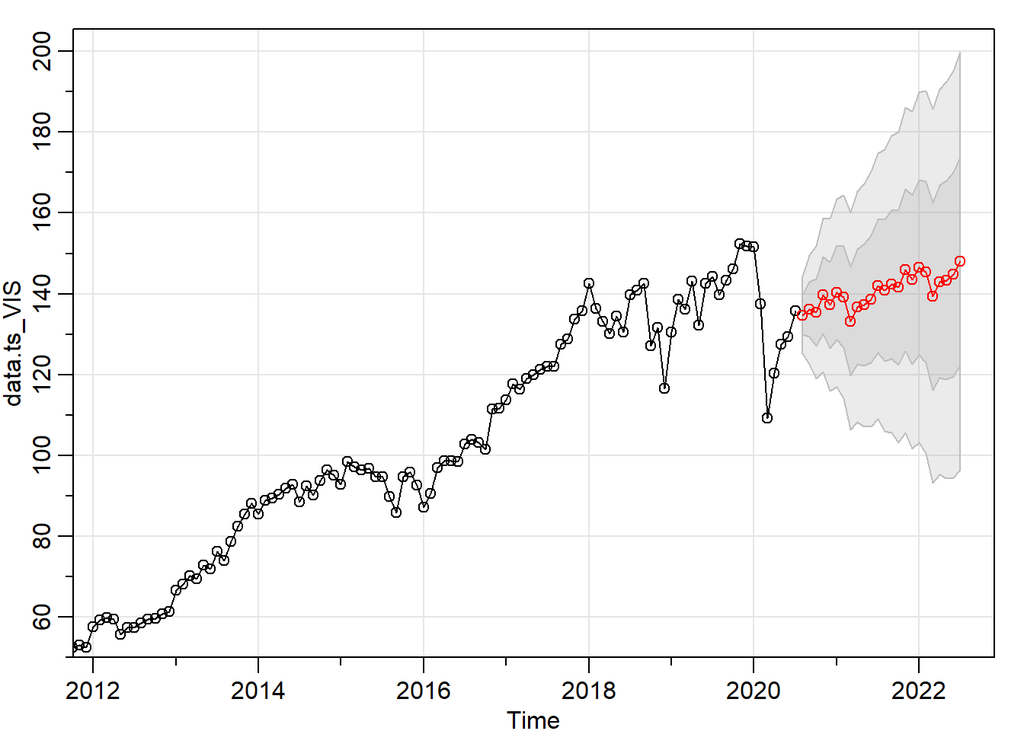

```
## $pred
##           Jan      Feb      Mar      Apr      May      Jun      Jul      Aug
## 2020                                                                134.7071
## 2021 140.2615 139.2295 133.2124 136.8151 137.2370 138.6769 141.9135 140.8805
## 2022 146.4350 145.4029 139.3858 142.9886 143.4104 144.8504 148.0869
##           Sep      Oct      Nov      Dec
## 2020 136.1344 135.4137 139.7025 137.2729
## 2021 142.3079 141.5871 145.8760 143.4464
## 2022
##
## $se
##            Jan       Feb       Mar       Apr       May       Jun       Jul
## 2020
## 2021 11.646116 12.579204 13.447703 14.263417 15.034940 15.768760 16.469916
## 2022 21.655698 22.403531 23.127194 23.828890 24.510506 25.173673 25.819813
##            Aug       Sep       Oct       Nov       Dec
## 2020  4.754714  6.724181  8.235227  9.509117 10.631447
## 2021 17.441786 18.362289 19.238569 20.076640 20.881101
## 2022
```

```r
sarima.for(data.ts_VIS, 24, 0,1,0,0,1,1,12)
```

### Accuracy of Forecast

The dataset used in this paper only includes adjusted closing prices until July 2020. To check whether the model has accurately forecasted the next few months, this section would check the difference between the predicted August 2020 prices and the actual August 2020 price.

#### VAW

VAW Prices, August 2020

|  | Predicted Adj. Price | Actual Adj. Price |
| --- | --- | --- |
| A | 128.1918 | 130.32 |

*Note: August 2020 actual adjusted closing prices are also sourced from Yahoo Finance*

Based on the forecast of the model, the forecasted August 2020 result is 128.1918. In the August 1 2020 adjusted closing price provided by Yahoo Finance, it is 130.32. The forecasted price is underpredicting the actual price by 2.13.

#### VCR

VCR Prices, August 2020

|  | Predicted Adj. Price | Actual Adj. Price |
| --- | --- | --- |
| A | 213.36 | 220.78 |

**Note: August 2020 actual adjusted closing prices are also sourced from Yahoo Finance*

Based on the forecast of the model, the forecasted August 2020 result is 213.3600. In the August 1 2020 adjusted closing price provided by Yahoo Finance, it is 220.78. The forecasted price is underpredicting the actual price by 7.42.

#### VDC

VDC Prices, August 2020

|  | Predicted Adj. Price | Actual Adj. Price |
| --- | --- | --- |
| A | 158.7104 | 161.73 |

**Note: August 2020 actual adjusted closing prices are also sourced from Yahoo Finance*

Based on the forecast of the model, the forecasted August 2020 result is 158.7104. In the August 1 2020 adjusted closing price provided by Yahoo Finance, it is 161.73. The forecasted price is underpredicting the actual price by 3.02.

#### VFH

VFH Prices, August 2020

|  | Predicted Adj. Price | Actual Adj. Price |
| --- | --- | --- |
| A | 57.60852 | 58.8 |

**Note: August 2020 actual adjusted closing prices are also sourced from Yahoo Finance*

Based on the forecast of the model, the forecasted August 2020 result is 57.60852. In the August 1 2020 adjusted closing price provided by Yahoo Finance, it is 58.80. The forecasted price is underpredicting the actual price by 1.19.

#### VHT

VHT Prices, August 2020

|  | Predicted Adj. Price | Actual Adj. Price |
| --- | --- | --- |
| A | 201.5882 | 204.47 |

**Note: August 2020 actual adjusted closing prices are also sourced from Yahoo Finance*

Based on the forecast of the model, the forecasted August 2020 result is 201.5882. In the August 1 2020 adjusted closing price provided by Yahoo Finance, it is 204.47. The forecasted price is underpredicting the actual price by 2.88.

#### VIS

VIS Prices, August 2020

[output not shown]

**Note: August 2020 actual adjusted closing prices are also sourced from Yahoo Finance*

## My Decision

### Short-Term Gains

If I want to earn quick profits, I would identify the ETFs with noticeable seasonal highs and lows. The two ETFs that has shown this characteristic is VCR and VFH.

### Long-Term Gains

If I were to hold a stock for a long time, I would consider the forecasted graphs that has an upward rising trend for the whole 24 months. The two stocks that share this characteristic is VDC and VHT.

## Conclusion

As someone who would want to maximize their income, I would slowly start buying VHT ETFs over the months. Once it is March 2021, I would sell all the VHT ETFs and buy VCR ETFs, holding it until July 2021 and selling it again. With the money gained from selling VCR, I would then buy VHT again and hold it until March 2022, and the cycle goes on.

I would not consider buying VAW, VFH and VIS due to the huge difference of the upper and lower limit. As a a risk averse person, having a wide difference in price possibilities makes me unnecessarily worried.

However, my decision may change after gaining more data over time as the model may become more accurate in its forecasts with data nearer to the actual month.